# Barcelona/LosAngelesUHIStudy

Make sure this notebook is located in the assignment folder, with subfolders “LA”, “Barcelona” and “Plots”.

## Packages

Download and install all necessary packages.

```r
list.of.packages <- c("RColorBrewer","classInt", "sp", "rgeos",
                      "sf","rgdal","geojsonio","tidyverse","raster",
                      "rasterVis","RStoolbox","plotly",
                      "htmlwidgets","magrittr","viridis", "tmap", "tmaptools", "shiny", "shinyjs")

#Checks whether any packages needed are not already downloaded&installed.
#Then installs all new packages.
new.packages <- list.of.packages[!(list.of.packages %in% installed.packages()[,"Package"])]
if(length(new.packages)) install.packages(new.packages)
```

Library all packages

```r
library(sf) #simplefeatures
library(sp)
library(rgeos)
library(rgdal)
library(geojsonio)
library(raster)
library(rasterVis)
library(RStoolbox)
library(plotly)
library(tidyverse)  #prerequisite for lots of packages
library(htmlwidgets)
library(RColorBrewer) #color scales
library(classInt)
library(magrittr) #Pipes - used for plotting
library(viridis)  #color scales
library(tmap)
library(tmaptools)
library(shiny)
library(shinyjs)
```

### Barcelona

Store GeoJSON of Barcelona outline into simple features object. This is used later for cropping the raster. Also need to change the projection of the barcelona outline to match the projection of raster file

```r
barcelonaSF <- st_read("Barcelona/Barcelona.geojson")
newProjection <- "+proj=utm +zone=31 +datum=WGS84 +units=m +no_defs"
barcelonaSF <- st_transform(barcelonaSF, newProjection)
```

## RASTER PRE-PROCESSING

```r
barcMTL <- readMeta("Barcelona/May_10_19/LC08_L1TP_198031_20190510_20190521_01_T1_MTL.txt")
espRS <- stackMeta("Barcelona/May_10_19/LC08_L1TP_198031_20190510_20190521_01_T1_MTL.txt")
#determine the SHV on the blue band (B2), with a dark prop of 1%
hazeDN <- estimateHaze(espRS, hazeBands = "B2_dn", darkProp = 0.01)
```

```r
barcelonaBound <- as(barcelonaSF, Class = "Spatial")
barcelonaExtent <- extent(barcelonaBound)
barcelonaRSCrop <- crop(atmCorrectedRS, barcelonaExtent)
barcelonaRSMask <- mask(barcelonaRSCrop, barcelonaBound)
```

## PROCESSING - SAVI, IBI, LST, UHI, UHS, UTFVI

Create Index Function.

```r
indexFunction <- function(band1, band2) {
  Index <- (band1 - band2) / (band1 + band2)
  return(Index)
}
```

SAVI used to detect vegetation over NDVI because more sensitive for areas where vegetation density is low (i.e cities) L = Constant that depends on amount of vegetation, 0 = highest vegetation density, 1 = lowest vegetation density. Generally taken as 0.5.

```r
L = 0.5
barcelonaSAVI <- ((barcelonaRSMask$B5_sre - barcelonaRSMask$B4_sre)*(1+L))/
                    (barcelonaRSMask$B5_sre + barcelonaRSMask$B4_sre + L)
```

MNDWI used to extract water from landsat8, more sensitive to areas such as cities where water is not commonly found.

```r
barcelonaMNDWI <- indexFunction(barcelonaRSMask$B3_sre,barcelonaRSMask$B6_sre)
```

```r
NDBI1 <- barcelonaNDBI + 1
SAVI1 <- barcelonaSAVI + 1
MNDWI1 <- barcelonaMNDWI + 1
barcelonaIBI <- ((NDBI1-((SAVI1+MNDWI1)/2))/
                   (NDBI1+((SAVI1+MNDWI1)/2)))
```

[output not shown]

##LST As we have performed atmospheric correction, we already have the Brightness temperature values in bands 10.#So no need to recalculate.

```r
barcBT1 <- barcelonaRSMask$B10_bt
```

Next calculate fractional vegetation value using SAVI values. This used to calculate emissivity.

```r
barcFracV=(barcelonaSAVI-0.2/0.5-0.2)^2
emiss1=0.004*barcFracV+0.986
```

p calculation and define lambda

```r
Boltzmann=1.38*10e-23
Plank=6.626*10e-34
c=2.998*10e8
p=Plank*(c/Boltzmann)
lambda=1.09e-5
```

Finally calculate LST equation and convert to celsius

```r
barcLST <-barcBT1/(1 +(lambda*barcBT1/p)*log(emiss1))
barcLST<-barcLST-273.15
```

## Determining UHI, non-UHI, UHS and UTFVI

```r
sd1 <- cellStats(barcLST, stat = "sd")
mean1 <- cellStats(barcLST, stat = "mean")
barcUHI <- barcLST > (mean1 + (0.5*sd1))     #(Ma,Kuang & Huang 2010)
barcNonUHI <- barcLST <= (mean1 + (0.5*sd1)) #(Guha,Govil & Mukherjee 2017)
barcUHS <- barcLST > (mean1 + (2*sd1))
barcUTFVI <- (barcLST - mean1)/mean1
```

## LOS ANGELES

Same process as barcelona, so putting all in one chunk (May take 10 mins or so to run.)

```r
laSF <- st_read("LA/LosAngeles.geojson")

laMTL <- readMeta("LA/May_30_19/LC08_L1TP_041036_20190530_20190605_01_T1_MTL.txt")
laRS <- stackMeta("LA/May_30_19/LC08_L1TP_041036_20190530_20190605_01_T1_MTL.txt")
newProjection <- "+proj=utm +zone=11 +datum=WGS84 +units=m +no_defs"
laSF <- st_transform(laSF, newProjection)
hazeDN1 <- estimateHaze(laRS, hazeBands = "B2_dn", darkProp = 0.01)
laCorRS <- radCor(laRS, metaData = laMTL,
                         method = "costz",hazeValues = hazeDN1, hazeBands = "B2_dn")

laBound <- as(laSF, Class = "Spatial")
laExtent <- extent(laBound)
laRSCrop <- crop(laCorRS, laExtent)
laRSMask <- mask(laRSCrop, laBound)

L = 0.5
laSAVI <- ((laRSMask$B5_sre - laRSMask$B4_sre)*(1+L))/
                    (laRSMask$B5_sre + laRSMask$B4_sre + L)
laNDBI <- indexFunction(laRSMask$B6_sre, laRSMask$B5_sre)
laMNDWI <- indexFunction(laRSMask$B3_sre,laRSMask$B6_sre)
NDBI2 <- laNDBI + 1
SAVI2 <- laSAVI + 1
MNDWI2 <- laMNDWI + 1
laIBI <- (NDBI2-(SAVI2+MNDWI2)/2)/
            (NDBI2+(SAVI2+MNDWI2)/2)

laBT <- laRSMask$B10_bt
laFracV=(laSAVI-0.2/0.5-0.2)^2
emiss2=0.004*laFracV+0.986
Boltzmann=1.38*10e-23
Plank=6.626*10e-34
c=2.998*10e8
p=Plank*(c/Boltzmann)
lambda=1.09e-5
laLST <-laBT/(1 +(lambda*laBT/p)*log(emiss2))
laLST<-laLST-273.15

sd2 <- cellStats(laLST, stat = "sd")
mean2 <- cellStats(laLST, stat = "mean")
laUHI <- laLST > (mean2 + (0.5*sd2))
laNonUHI <- laLST <= (mean2 + (0.5*sd2))
laUHS <- laLST > (mean2 + (2*sd2))
laUTFVI <- (laLST - mean2)/mean2
```

## PLOTTING

Create map functions for plotting barcelona and LA, so that dont need to rewrite everytime. Store colour palettes and SAVI breaks too.

```r
createMap <- function(ras, geoshp, colour,br, legTitle, Mtitle){
  tm_shape(ras) +
    tm_raster(style = "fixed", title = Mtitle,

              palette = colour, midpoint = NA, breaks = br)+
    tm_legend(outside = FALSE, legend.position = c("right", "bottom"))+
    tm_shape(geoshp) +
    tm_borders(alpha =  0.4, col = "black") +
    tm_layout(inner.margins = c(0.1, 0.1, 0.1, 0.1),
              title = legTitle,
              title.size = 1.1,
              title.position = c("center", "top")) +
    tm_compass(type = "4star", size = 3, text.size = 1,position = c("left", "top")) +
    tm_scale_bar(position = c("left","bottom"))

}
createMap2 <- function(ras, geoshp, colour,br, legTitle, Mtitle){
  tm_shape(ras) +
    tm_raster(style = "fixed", title = Mtitle,

              palette = colour, midpoint = NA, breaks = br)+
    tm_legend(outside = FALSE, legend.position = c("left", "bottom"))+
    tm_shape(geoshp) +
    tm_borders(alpha =  0.4, col = "black") +
    tm_layout(inner.margins = c(0.08, 0.1, 0.1, 0.1),
              title = legTitle,
              title.size = 1.1,
              title.position = c("center", "top")) +
    tm_compass(type = "4star", size = 3, text.size = 1,position = c("left", "top")) +
    tm_scale_bar(position = c("right","bottom"))

}
#Colour palettes
RedGreen <- c("#A93226","#E67E22","#F1C40F","#52BE80","#196F3D")
GreenRed <- c("#196F3D","#52BE80","#F1C40F","#E67E22","#A93226")
#Break points for SAVI threshold intervals
cuts = c(-1,0,0.1, 0.2, 0.3,1)
```

Create Maps for LST, IBI, SAVI distributions

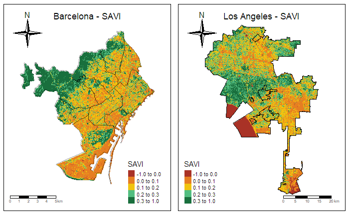

```r
SAVImap1 <- createMap(barcelonaSAVI, barcelonaSF, RedGreen, cuts, "Barcelona - SAVI","SAVI")
SAVImap2 <- createMap2(laSAVI, laSF, RedGreen, cuts, "Los Angeles - SAVI", "SAVI")

SAVIplot <- tmap_arrange(SAVImap1, SAVImap2, ncol = 2)
SAVIplot
```

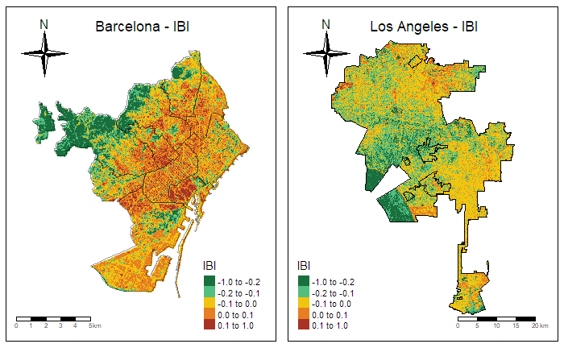

```r
IBImap1 <- createMap(barcelonaIBI, barcelonaSF, GreenRed, c(-1,-0.2,-0.1,0,0.1,1), "Barcelona - IBI", "IBI")
IBImap2 <- createMap2(laIBI, laSF, GreenRed, c(-1,-0.2,-0.1,0,0.1,1), "Los Angeles - IBI", "IBI")
IBIplot <- tmap_arrange(IBImap1, IBImap2, ncol=2)
IBIplot
```

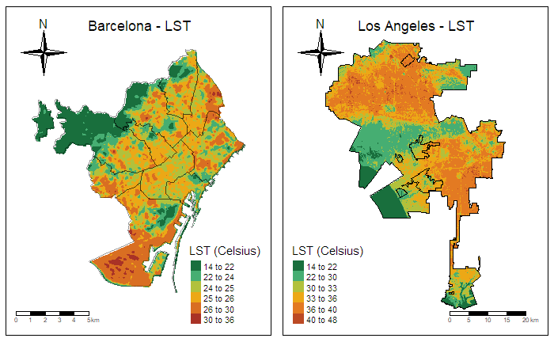

```r
LSTmap1 <- createMap(barcLST, barcelonaSF, GreenRed, c(14,22, 24, 25, 26,30, 36),"Barcelona - LST", "LST (Celsius)")
LSTmap2 <- createMap2(laLST, laSF, GreenRed, c(14,22,30,33,36,40,48), "Los Angeles - LST", "LST (Celsius)")
LSTmap <- tmap_arrange(LSTmap1, LSTmap2, ncol=2)
LSTmap
```

Crop LST to UHI map to work out midpoints for next plot.

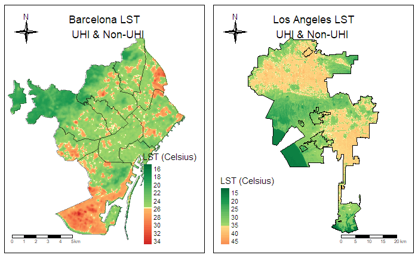

```r
bUHIcrop <- mask(barcLST, barcUHI, maskvalue = 0, updatevalue = NA)
bNUHIcrop <- mask(barcLST,barcUHI, maskvalue = 1, updatevalue = NA)
lUHIcrop <- mask(laLST, laUHI, maskvalue = 0, updatevalue = NA)
lNUHIcrop <- mask(laLST, laUHI, maskvalue = 1, updatevalue = NA)
bUHScrop <- mask(barcLST, barcUHS, maskvalue = 0, updatevalue = NA)
lUHScrop <- mask(laLST, laUHS, maskvalue = 0, updatevalue = NA)
#Simply find minimum value of bUHIcrop and lUHIcrop to use as midpoints in next plot.
UHImap1 <- tm_shape(barcLST) +
  tm_raster(style = "cont", title = "LST (Celsius)", midpoint = 25.764, palette = "-RdYlGn",n = 9, contrast = c(0.4, 1)) +
  tm_legend(outside = FALSE, legend.position = c("right", "bottom"))+
  tm_shape(barcelonaSF) +
  tm_borders(alpha =  0.4, col = "black") +
  tm_layout(inner.margins = c(0.05, 0.02, 0.13, 0.1),
            title = "Barcelona LST\n UHI & Non-UHI",
            title.size = 1.1,
            title.position = c("center", "top")) +
  tm_compass(type = "4star", size = 2.5, text.size = 0.8,position = c("left", "top")) +
  tm_scale_bar(position = c("left","bottom"))


UHImap2 <- tm_shape(laLST) +
  tm_raster(style = "cont", title = "LST (Celsius)", midpoint = 35.51689, palette = "-RdYlGn",n = 9, contrast = c(0.4, 1)) +
  tm_legend(outside = FALSE, legend.position = c("left", "bottom"))+
  tm_shape(laSF) +
  tm_borders(alpha =  0.4, col = "black") +
  tm_layout(inner.margins = c(0.08, 0.1, 0.13, 0.1),
            title = "Los Angeles LST\n UHI & Non-UHI",
            title.size = 1.1,
            title.position = c("center", "top")) +
  tm_compass(type = "4star", size = 2.5, text.size = 0.8,position = c("left", "top")) +
  tm_scale_bar(position = c("right","bottom"))

UHIplot <- tmap_arrange(UHImap1, UHImap2, ncol = 2)
UHIplot
```

UTFVI and UHS plots

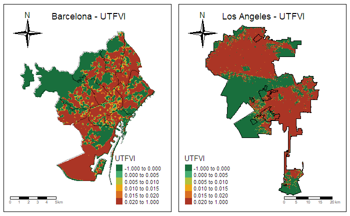

```r
UTFVIbins <- c(-1,0,0.005,0.01,0.015,0.02,1)
UTFVImap1 <- createMap(barcUTFVI, barcelonaSF, GreenRed, UTFVIbins, "Barcelona - UTFVI", "UTFVI")
UTFVImap2 <- createMap2(laUTFVI, laSF, GreenRed, UTFVIbins, "Los Angeles - UTFVI", "UTFVI")
UTFVIplot <- tmap_arrange(UTFVImap1, UTFVImap2, ncol = 2)
UTFVIplot
```

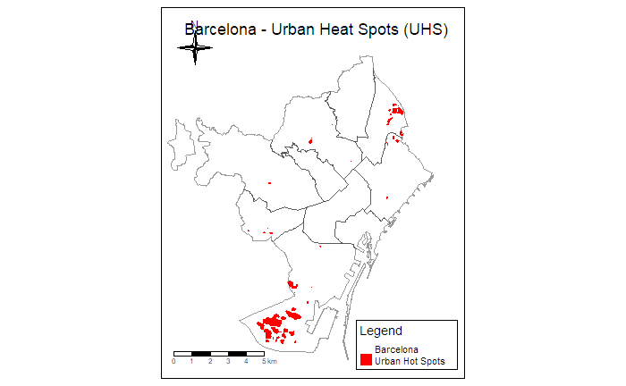

```r
UHSmap1 <- tm_shape(barcUHS) +
  tm_raster(style = 'cont',title = "Legend" ,palette = c("white", "red"), labels = c("Barcelona","Urban Hot Spots"))+
  tm_legend(outside = F, legend.position = c("right", "bottom"), frame = "black")+
  tm_shape(barcelonaSF) +
  tm_borders(alpha = 0.4, col = "black") +
  tm_layout(inner.margins = c(0.05, 0.02, 0.13, 0.1),
            title = "Barcelona - Urban Heat Spots (UHS)",
            title.size = 1.1,
            title.position = c("center", "top")) +
  tm_compass(type = "4star", size = 2.5, text.size = 0.8,position = c("left", "top")) +
  tm_scale_bar(position = c("left","bottom"))

UHSmap2 <- tm_shape(laUHS) +
  tm_raster(style = 'cont',title = "Legend" ,palette = c("white", "red"), labels = c("Los Angeles","Urban Hot Spots"))+
  tm_legend(outside = F, legend.position = c("right", "bottom"), frame = "black")+
  tm_shape(laSF) +
  tm_borders(alpha = 0.4, col = "black") +
  tm_layout(inner.margins = c(0.05, 0.2, 0.13, 0.2),
            title = "Los Angeles - Urban Heat Spots (UHS)",
            title.size = 1.1,
            title.position = c("center", "top")) +
  tm_compass(type = "4star", size = 2.5, text.size = 0.8,position = c("left", "top")) +
  tm_scale_bar(position = c("left","bottom"))
UHSmap1
```

[output not shown]

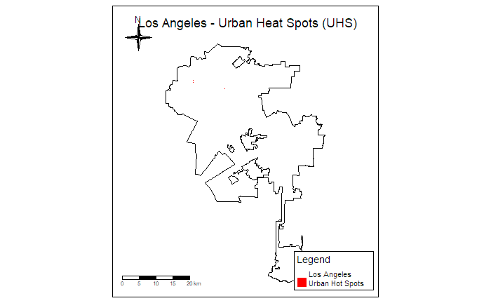

```r
UHSmap2
```

Work out the area % of UTFVI

```r
utfviDF1 <- as.data.frame(na.omit(values(barcUTFVI)))
utfviDF2 <- as.data.frame(na.omit(values(laUTFVI)))

bclass1 <- sum(utfviDF1[] < 0)
bclass2 <- sum(utfviDF1[] >= 0 & utfviDF1[] < 0.005)
bclass3 <- sum(utfviDF1[] >= 0.005 & utfviDF1[] < 0.01)
bclass4 <- sum(utfviDF1[] >= 0.01 & utfviDF1[] < 0.015)
bclass5 <- sum(utfviDF1[] >= 0.015 & utfviDF1[] < 0.02)
bclass6 <- sum(utfviDF1[] >= 0.02)

bTot <- bclass1+bclass2+bclass3+bclass4+bclass5+bclass6
b1 <- (bclass1/bTot)*100
b2 <- (bclass2/bTot)*100
b3 <- (bclass3/bTot)*100
b4 <- (bclass4/bTot)*100
b5 <- (bclass5/bTot)*100
b6 <- (bclass6/bTot)*100

lclass1 <- sum(utfviDF2[] < 0)
lclass2 <- sum(utfviDF2[] >= 0 & utfviDF2[] < 0.005)
lclass3 <- sum(utfviDF2[] >= 0.005 & utfviDF2[] < 0.01)
lclass4 <- sum(utfviDF2[] >= 0.01 & utfviDF2[] < 0.015)
lclass5 <- sum(utfviDF2[] >= 0.015 & utfviDF2[] < 0.02)
lclass6 <- sum(utfviDF2[] >= 0.02)

lTot <- lclass1+lclass2+lclass3+lclass4+lclass5+lclass6
l1 <- (lclass1/lTot)*100
l2 <- (lclass2/lTot)*100
l3 <- (lclass3/lTot)*100
l4 <- (lclass4/lTot)*100
l5 <- (lclass5/lTot)*100
l6 <- (lclass6/lTot)*100

b1
```

```
[1] 39.15756
```

```r
b2
```

```
[1] 2.934981
```

```r
b3
```

```
[1] 3.194314
```

```r
b4
```

```
[1] 3.669611
```

```r
b5
```

```
[1] 4.063479
```

```r
b6
```

```
[1] 46.98005
```

```r
l1
```

```
[1] 37.84975
```

```r
l2
```

```
[1] 1.136798
```

```r
l3
```

```
[1] 1.134034
```

```r
l4
```

```
[1] 1.170425
```

```r
l5
```

```
[1] 1.218332
```

```r
l6
```

```
[1] 57.49066
```

## Linear relationships

stack all data that you want to explore the relationship of, and then convert to dataframe. remove null values too.

```r
barcStack <- stack(barcLST, barcelonaSAVI, barcelonaIBI)
barcDF <- as.data.frame(na.omit(values(barcStack)))
laStack <- stack(laLST, laSAVI, laIBI)
laDF <- as.data.frame(na.omit(values(laStack)))
#barcelona
bTempVeg <- lm(layer.2~layer.1, data = barcDF)
summary(bTempVeg)
```

```
Call:
lm(formula = layer.2 ~ layer.1, data = barcDF)

Residuals:
     Min       1Q   Median       3Q      Max
-0.52341 -0.05978 -0.00969  0.05418  0.62767

Coefficients:
              Estimate Std. Error t value Pr(>|t|)
(Intercept)  0.9672208  0.0026389   366.5   <2e-16 ***
layer.1     -0.0317552  0.0001071  -296.5   <2e-16 ***
---
Signif. codes:  0 ‘***’ 0.001 ‘**’ 0.01 ‘*’ 0.05 ‘.’ 0.1 ‘ ’ 1

Residual standard error: 0.0902 on 112980 degrees of freedom
Multiple R-squared:  0.4376,    Adjusted R-squared:  0.4376
F-statistic: 8.79e+04 on 1 and 112980 DF,  p-value: < 2.2e-16
```

```r
bTempIBI <- lm(layer.3 ~ layer.1, data = barcDF)
summary(bTempIBI)
```

```
Call:
lm(formula = layer.3 ~ layer.1, data = barcDF)

Residuals:
     Min       1Q   Median       3Q      Max
-0.52177 -0.06201 -0.00577  0.06710  0.38978

Coefficients:
              Estimate Std. Error t value Pr(>|t|)
(Intercept) -0.7474718  0.0026264  -284.6   <2e-16 ***
layer.1      0.0286906  0.0001066   269.1   <2e-16 ***
---
Signif. codes:  0 ‘***’ 0.001 ‘**’ 0.01 ‘*’ 0.05 ‘.’ 0.1 ‘ ’ 1

Residual standard error: 0.08977 on 112980 degrees of freedom
Multiple R-squared:  0.3907,    Adjusted R-squared:  0.3907
F-statistic: 7.244e+04 on 1 and 112980 DF,  p-value: < 2.2e-16
```

```r
#LA
lTempVeg <- lm(layer.2~layer.1, data = laDF)
summary(lTempVeg)
```

```
Call:
lm(formula = layer.2 ~ layer.1, data = laDF)

Residuals:
     Min       1Q   Median       3Q      Max
-0.54604 -0.08296 -0.00293  0.07586  0.56644

Coefficients:
              Estimate Std. Error t value Pr(>|t|)
(Intercept)  1.951e-01  5.513e-04  353.86   <2e-16 ***
layer.1     -6.143e-04  1.664e-05  -36.93   <2e-16 ***
---
Signif. codes:  0 ‘***’ 0.001 ‘**’ 0.01 ‘*’ 0.05 ‘.’ 0.1 ‘ ’ 1

Residual standard error: 0.1184 on 1519617 degrees of freedom
Multiple R-squared:  0.0008965, Adjusted R-squared:  0.0008958
F-statistic:  1363 on 1 and 1519617 DF,  p-value: < 2.2e-16
```

```r
lTempIBI <- lm(layer.3 ~ layer.1, data = laDF)
summary(lTempIBI)
```

```
Call:
lm(formula = layer.3 ~ layer.1, data = laDF)

Residuals:
     Min       1Q   Median       3Q      Max
-0.59580 -0.04203 -0.00119  0.04052  0.41666

Coefficients:
              Estimate Std. Error t value Pr(>|t|)
(Intercept) -3.362e-01  3.276e-04 -1026.5   <2e-16 ***
layer.1      7.524e-03  9.885e-06   761.2   <2e-16 ***
---
Signif. codes:  0 ‘***’ 0.001 ‘**’ 0.01 ‘*’ 0.05 ‘.’ 0.1 ‘ ’ 1

Residual standard error: 0.07034 on 1519617 degrees of freedom
Multiple R-squared:  0.276, Adjusted R-squared:  0.276
F-statistic: 5.794e+05 on 1 and 1519617 DF,  p-value: < 2.2e-16
```

## Write out plots

```r
tmap_save(SAVIplot, filename = "Plots/SAVIplot.png")
tmap_save(UHIplot, filename = "Plots/UHIplot.png")
tmap_save(UHSmap1, filename = "Plots/UHSbarcelona.png")
tmap_save(UHSmap2, filename = "Plots/UHSla.png")
tmap_save(IBIplot, filename = "Plots/IBIplot.png")
tmap_save(LSTmap, filename = "Plots/LSTplot.png")
tmap_save(UTFVIplot, filename = "Plots/UTFVIplot.png")
```